# Rendu Travaux Pratiques 3

#### Règles de rendu

- Chaque TP donne lieu à un bref compte-rendu portant sur certaines questions posées dans l’énoncé du TPs.
- Le compte-rendu doit être complété à partir du texte de l’énoncé. Les codes R doivent être inclus dans le texte du compte-rendu (menu **Insert**) et commentés avec précision. **Les commentaires compteront pour une part importante dans la note**.
- Le compte-rendu doit être déposé **sur TEIDE à la fin de la séance de TP**. Les rendus en retard seront fortement pénalisés.
- Le compte-rendu doit être déposé **sur TEIDE au format HTML uniquement**. Utiliser la fonction **Preview** ou **knitr** du menu de rstudio pour obtenir le document au format souhaité. **Les fichiers “source” (Rmd) ne seront pas acceptés par les correcteurs**.

```r
library(isd)
library(magrittr)
```

#### Exercice 1 : Données simulées (knn)

Dans cet exercice, on fixera la graine du générateur aléatoire pour la simulation du modèle de Hastie.

```r
set.seed(seed = 2149)

x <- isd::rhastib(n_train = 200,
                    n_test = 200,
                    n_subclass = 10,
                    sigma2 = 0.05)
```

- Méthode `knn` : Pour $k = 1,\dots, 30$, calculer l’erreur de classification et la perte log loss à partir de l’ensemble test (on modifiera les probabilités 0 ou 1 pour éviter les valeurs “Inf”). Représenter ces résultats sous la forme de graphes “accuracy” et “logloss” en fonction de $k$.

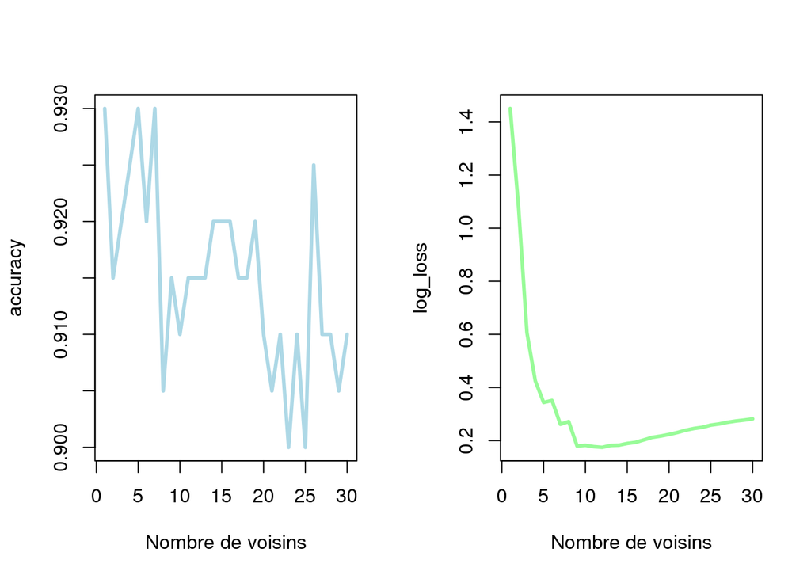

```r
accuracy <- NULL
log_loss <-  NULL

for (k in 1:30){

  #on calcule une classification du test set, grâce à un modèle knn avec k voisins s'entrainant sur le train set
  mod_knn <- class::knn(train = x$train,
                        test = x$test,
                        cl = x$class_train,
                        k = k,
                        prob = TRUE)

  #on met les classes prédites dans class_pred et les probabilités associées dans prob_class
  class_pred <- mod_knn
  prob_class <- attr(mod_knn,"prob")

  # les probabilités sont modifiées pour éviter Inf
  prob_class[prob_class == 1] <- 1 - 1e-09
  prob_class[prob_class == 0] <- 1e-09

  # un vecteur logique montrant si la prédiction est juste
  boo <- (class_pred == x$class_test)

  #l'accuracy correspond à l'exactitude de la prédiction
  accuracy[k] <- mean(class_pred == x$class_test)

  log_loss[k] <- - mean(boo*log(prob_class)) - mean((!boo)*log(1 - prob_class))
}

par(mfrow = c(1, 2)) # divise la fenetre en 1 ligne 2 colonnes
plot(accuracy, col = "lightblue", type = "l", lwd = 3, xlab = "Nombre de voisins")
plot(log_loss, col = "palegreen", type = "l", lwd = 3, xlab = "Nombre de voisins")
```

- Quel choix de $k$ vous parait le plus pertinent pour la simulation effectuée ?

#### Exercice 2 : Données simulées (lda)

- Méthode `lda` : Calculer le taux de bonne classification et la perte log loss sur l’ensemble test.

```r
require(MASS)
help(lda)

#on entraîne un modèle prédictif avec la méthode lda sur le train set
    mod_lda <- MASS::lda(x = x$train,
                         grouping = x$class_train)

#   on applique ce moède sur le test set et on récupère les prédictions
    pred <- predict(mod_lda, newdata = x$test)

# Les  probabilités correspondent aux classes des variables testées
    prob_class <- pred$posterior

# on mesure la précision comme étant le pourcentage de bonne prédictions
  accuracy <- mean(x$class_test == pred$class)
  cat("Accuracy = ", accuracy, "\n")
```

```
## Accuracy =  0.9
```

```r
# on calcule la log loss (perte d'information) associée à ce modèle
  log_loss <- -mean( (x$class_test == "lightblue")*log(prob_class[,1]) + (x$class_test == "orange")*log(prob_class[,2]) )
  cat("Logloss = ", log_loss, "\n")
```

```
## Logloss =  0.2619534
```

#### Exercice 3 : Données simulées (nnet)

- Méthode `nnet` : Pour `decay`$ = 0, 0.00001, 0.0001, 0.001, 0.01, 0.1, 1$, calculer le taux de bonne classification et la perte log loss sur l’ensemble test. Représenter ces résultats sous forme de tableau (accuracy/logloss en fonction de `decay`).

```r
require(nnet)
accuracy <- NULL
log_loss <-  NULL

  decay <- c(0, 10^(-(6:0)))

# On ajuste des modeles nnet pour 7 valeurs du paramètre decay
# decay est un paramètre de régularisation

  for (lambda in decay){

    # neural net
    mod_nnet <- nnet( x = x$train,
                      y = (x$class_test=="orange"),
                      size = 30,
                      decay = lambda,
                      maxit = 500,
                      entropy = TRUE,
                      trace = FALSE)

    # probabilité de prédiction en orange
    prob_class <- predict(mod_nnet, newdata = data.frame(x$test))

    prob_class[prob_class > 1 - 1e-08]  <- 1 - 1e-08
    prob_class[prob_class < 1e-08] <- 1e-08

    # on calcule l'accuracy, sachant qu'un vecteur est "orange" si sa probabilité calculée est supérieure à 0.5
    accuracy <- c(accuracy,
                  mean((x$class_test=="orange") == (prob_class > 0.5)))

    # calul de la perte log loss
    log_loss <- c( log_loss,
                - mean((x$class_test == "lightblue")*log(1 - prob_class)) - mean((x$class_test == "orange")*log(prob_class)) )
  }


# on créer un tableau affichant l'accuracy et la logloss pour chaque valeur de decay
  names(accuracy) <- as.character(decay)
  names(log_loss) <- as.character(decay)

  data.frame(accuracy, log_loss)  %>% knitr::kable(digit = 2)
```

|  | accuracy | log_loss |
| --- | --- | --- |
| 0 | 0.91 | 1.62 |
| 1e-06 | 0.92 | 1.30 |
| 1e-05 | 0.90 | 1.44 |
| 1e-04 | 0.92 | 0.88 |
| 0.001 | 0.92 | 0.45 |
| 0.01 | 0.91 | 0.22 |
| 0.1 | 0.89 | 0.19 |
| 1 | 0.90 | 0.28 |

#### Exercice 4 : “Wisconsin Breast Cancer Database”

```r
library(mlbench)
data(BreastCancer)

boo_na <- !apply(BreastCancer, 1, anyNA)
breast_cancer <- BreastCancer[boo_na,-1]

# on prend un échantillon aléatoire de 546 personnes
  cancer_samp <- sample(1:nrow(breast_cancer), 546)

#que l'on utilise pour séparer en train et test sets
  cancer_train <- breast_cancer[cancer_samp,]
  cancer_test <- breast_cancer[-cancer_samp,]
```

- À l’aide de l’ensemble test, évaluer les taux de classification et de perte log loss pour les méthodes `lda`, `nnet` et `knn`. Pour `knn` et `nnet`, utiliser, dans un premier temps, les paramètres $k = 15$ et `decay`$=0.01$.

```r
# lda
      mod_lda <- MASS::lda(cancer_train[,10] ~., data = cancer_train[,-10])

      pred_lda <- predict(mod_lda, newdata = cancer_test[,-10])$class

      accuracy_lda <- mean(pred_lda == cancer_test$Class)

      prob_lda <- predict(mod_lda, newdata = cancer_test[,-10])$posterior

      prob_lda[prob_lda > 1 - 1e-08]  <- 1 - 1e-08
      prob_lda[prob_lda < 1e-08] <- 1e-08

      log_loss_lda <- -mean((cancer_test$Class == "benign")*log(prob_lda[,1]) + mean((cancer_test$Class == "malignant")*log(prob_lda[,2])))

      accuracy_lda
```

```
## [1] 0.9416058
```

```r
      log_loss_lda
```

```
## [1] 0.5982034
```

```r
# nnet
      y <-  as.numeric(cancer_train$Class == "malignant")

      mod_nnet <- nnet::nnet(x = cancer_train[,-10],
                             y = y,
                             size = 30,
                             entropy = TRUE,
                             decay = 0.01,
                             trace = FALSE)

      prob_nnet <- predict(mod_nnet, cancer_test[,-10])
      prob_nnet[prob_nnet == 0] <- 1e-08
      prob_nnet[prob_nnet == 1] <- 1 - 1e-08

      accuracy_nnet <- mean((prob_nnet>0.5) == (cancer_test$Class == "malignant"))

      log_loss_nnet <- -mean((cancer_test$Class == "benign")*log(1 - prob_nnet) + (cancer_test$Class == "malignant")*log(prob_nnet))

      accuracy_nnet
```

```
## [1] 0.9489051
```

```r
      log_loss_nnet
```

```
## [1] 0.1920983
```

```r
# knn
     mod_knn <- class::knn(cancer_train[,-10],
                            cancer_test[,-10],
                            cancer_train$Class,
                            k = 15,
                            prob = TRUE)

      accuracy_knn <- mean(mod_knn == cancer_test$Class)
      prob_class <- attr(mod_knn, "prob")
      prob_class[prob_class == 1] <-  1 - 1e-08

      log_loss_knn <- - mean( (mod_knn == cancer_test$Class)*log(prob_class) + (mod_knn != cancer_test$Class)*log(1-prob_class) )

      accuracy_knn
```

```
## [1] 0.9489051
```

```r
      log_loss_knn
```

```
## [1] 0.2291922
```

- Reporter sous forme de tableau avec des valeurs arrondies les valeurs des taux de classification et de perte log loss obtenues pour les méthodes `knn`, `lda`, `nnet` (dans cet ordre). Quel choix de prédicteur vous parait être le meilleur ? Justifier.

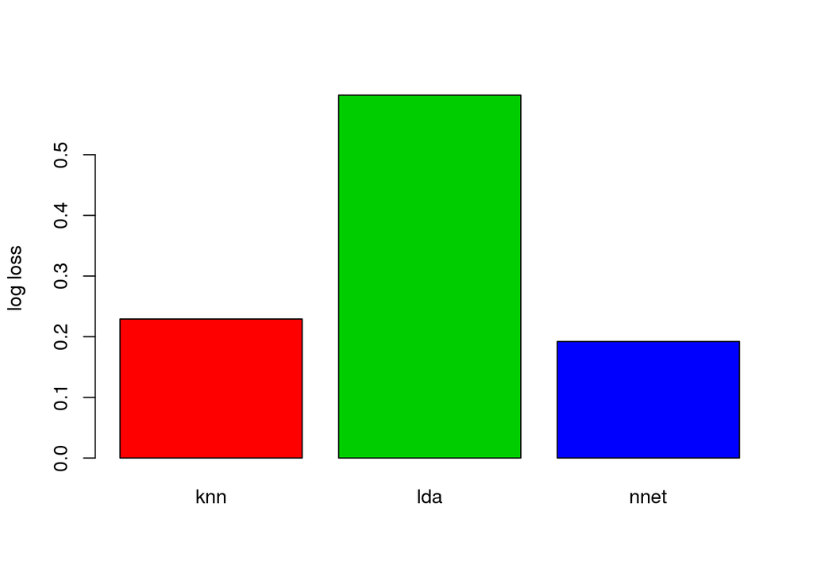

```r
  log_loss <-  c(log_loss_knn,log_loss_lda,log_loss_nnet)

  names(log_loss) <-  c("knn", "lda", "nnet")

  barplot(log_loss, col = 2:4, ylab = "log loss")
```

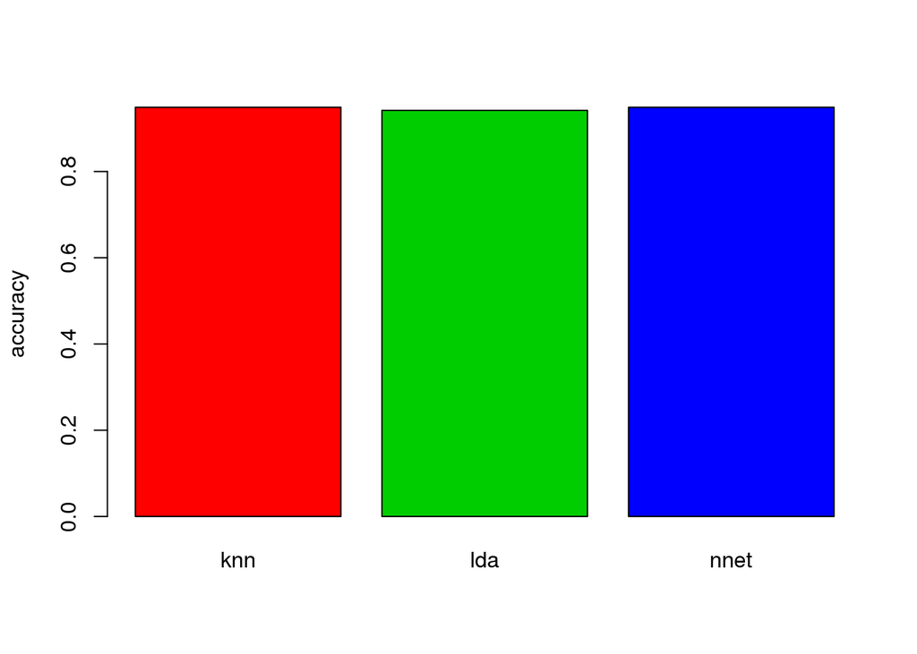

```r
  accuracy <- c(accuracy_knn,accuracy_lda,accuracy_nnet)

  names(accuracy) <-  c("knn", "lda", "nnet")

  barplot(accuracy, col = 2:4, ylab = "accuracy")
```

```r
data.frame(log_loss, accuracy) %>% round(2)
```

```
##      log_loss accuracy
## knn      0.23     0.95
## lda      0.60     0.94
## nnet     0.19     0.95
```

Deux modèles se démarquent, le knn et le nnet, car ils ont une log loss très faible et une bonne précision.

- Pour `knn` et `nnet`, explorer les paramètres de “complexité” ($k$ et `decay`) conduisant aux meilleures performances. Reporter les performances des modèles correspondant dans un tableau.

```r
#nnet
accuracy <- NULL
log_loss <-  NULL

  decay <- c(0.02*(1:5),0.2*(1:5))

# On ajuste des modeles nnet pour 7 valeurs du paramètre decay
# decay est un paramètre de régularisation

  for (lambda in decay){

    y <-  as.numeric(cancer_train$Class == "malignant")

      mod_nnet <- nnet::nnet(x = cancer_train[,-10],
                             y = y,
                             size = 30,
                             entropy = TRUE,
                             decay = lambda,
                             trace = FALSE)

    prob_nnet <- predict(mod_nnet, cancer_test[,-10])
    prob_nnet[prob_nnet == 0] <- 1e-08
    prob_nnet[prob_nnet == 1] <- 1 - 1e-08

    accuracy <- c(accuracy,mean((prob_nnet>0.5) == (cancer_test$Class == "malignant")))

    log_loss <- c(log_loss,-mean((cancer_test$Class == "benign")*log(1 - prob_nnet) + (cancer_test$Class == "malignant")*log(prob_nnet)))
  }


# on créer un tableau affichant l'accuracy et la logloss pour chaque valeur de decay
  names(accuracy) <- as.character(decay)
  names(log_loss) <- as.character(decay)

  data.frame(accuracy, log_loss)  %>% knitr::kable(digit = 2)
```

[output not shown]

```r
accuracy_knn <- NULL
log_loss_knn <-  NULL

# On ajuste des modeles knn pour 10 valeurs du paramètre neighbour
# neighbour est un paramètre de régularisation

  neighbour=c(5+(1:10))
  neighbour
```

```
##  [1]  6  7  8  9 10 11 12 13 14 15
```

```r
  for (k in neighbour){

    mod_knn <- class::knn(cancer_train[,-10],
                            cancer_test[,-10],
                            cancer_train$Class,
                            k = k,
                            prob = TRUE)

      accuracy_knn <- c(accuracy_knn, mean(mod_knn == cancer_test$Class))
      prob_class <- attr(mod_knn, "prob")
      prob_class[prob_class == 1] <-  1 - 1e-08

      log_loss_knn <- c(log_loss_knn,- mean( (mod_knn == cancer_test$Class)*log(prob_class) + (mod_knn != cancer_test$Class)*log(1-prob_class) ))
  }


# on créer un tableau affichant l'accuracy et la logloss pour chaque valeur de neighbour
  names(accuracy_knn) <- as.character(neighbour)
  names(log_loss_knn) <- as.character(neighbour)

  data.frame(accuracy_knn, log_loss_knn)  %>% knitr::kable(digit = 2)
```

[output not shown]

#### Défi “Wisconsin Breast Cancer Database”

```r
rm(cancer_test)
rm(cancer_train)
data(cancer_train)
data(cancer_test)
```

- Pour les méthodes `knn`, `lda`, `nnet`, calculer les probabilités de la classe “malignant” pour chaque élément de l’ensemble test. On choisira les paramètres `k` et `decay` donnant les meilleures performances possibles.

```r
#on prendra les valeurs k et decay trouvées précédemment

# entrainement d'un modèle à paramétrer
mod_knn <- class::knn(cancer_train[,-10],
                            cancer_test[,-10],
                            cancer_train$Class,
                            k = 11,
                            prob = TRUE)

# proba de la classe "malignant" pour l'ensemble test
prob_knn <- attr(mod_knn, "prob")
prob_knn[prob_knn == 1] <-  1 - 1e-08

# entrainement d'un modèle à paramétrer
y <-  as.numeric(cancer_train$Class == "malignant")
mod_nnet <-  nnet::nnet(x = cancer_train[,-10],
                             y = y,
                             size = 30,
                             entropy = TRUE,
                             decay = 1,
                             trace = FALSE)

# proba de la classe "malignant" pour l'ensemble test
prob_nnet <- predict(mod_nnet, cancer_test)

mod_lda <- MASS::lda(cancer_train[,10] ~., data = cancer_train[,-10])

prob_lda <- predict(mod_lda, newdata = cancer_test[,-10])$posterior
prob_lda[prob_lda > 1 - 1e-08]  <- 1 - 1e-08
prob_lda[prob_lda < 1e-08] <- 1e-08
```

- Pour les méthodes `knn`, `lda`, `nnet`, appliquer la fonction `eval_cancer` et présenter les résultat sous forme de tableau (`data.frame`).

```r
# accuracy et log loss sur l'ensemble test
acc_knn = eval_cancer(prob_knn)$accuracy
acc_nnet = eval_cancer(prob_nnet)$accuracy
acc_lda = eval_cancer(prob_lda[,2])$accuracy
loss_knn = eval_cancer(prob_knn)$log.loss
loss_nnet = eval_cancer(prob_nnet)$log.loss
loss_lda = eval_cancer(prob_lda[,2])$log.loss

res=data.frame("knn"=c(acc_knn,loss_knn),"nnet"=c(acc_nnet,loss_nnet),"lda"=c(acc_lda,loss_lda),row.names = c("accuracy","log.loss"))
res
```

```
##               knn       nnet       lda
## accuracy  0.24000 1.00000000 0.9466667
## log.loss 13.35076 0.05702731 0.3364833
```

On obtient un excellent résultat pour le réseau de neurone. Le résultat du lda est acceptable. La méthode knn semble être incapable de prédire quoi que ce soit.